# Twitter Sentiment Analysis

In this project I will attempt to predict the price of TSLA, by analyzing sentiment of tweets from the previous day. Tweets will be retrieved from twitter by API calls. Tweets from the following Twitter accounts will be analyzed: @YahooFinance, @MarketWatch, @SeekingAlpha, @elonmusk.

Read in packages that are necessary for this project.

```r
library(tidyverse)
library(httr)
library(jsonlite)
library(rtweet)
library(tidyquant)
library(lubridate)
library(tidytext)
```

Connect to Twitter API with app details that are not included in this markdown output.

```r
myToken = create_token(app = app_name,
             consumer_key = key,
             consumer_secret = secret,
             access_token = access,
             access_secret = access_secret)
```

Use the API to retrieve up to 10,000 tweets from each account (10,000 is the max allowed, the API will likely provide less). Look at the head and length of this dataframe and decide which variables to keep.

```r
tmls <- get_timelines(c("YahooFinance", "MarketWatch", "SeekingAlpha", "elonmusk"), n = 10000, include_rts = F)
head(tmls)
```

```
## # A tibble: 6 × 90
##   user_id  status_id           created_at          screen_name  text      source
##   <chr>    <chr>               <dttm>              <chr>        <chr>     <chr>
## 1 19546277 1475285302285672450 2021-12-27 02:00:00 YahooFinance Here’s w… Twitt…
## 2 19546277 1475179610169954304 2021-12-26 19:00:01 YahooFinance Elon Mus… Twitt…
## 3 19546277 1475167228798681092 2021-12-26 18:10:49 YahooFinance What is … Socia…
## 4 19546277 1475157985475416065 2021-12-26 17:34:05 YahooFinance Boston S… Socia…
## 5 19546277 1475152713381994503 2021-12-26 17:13:08 YahooFinance NY resta… Socia…
## 6 19546277 1475147392110542853 2021-12-26 16:51:59 YahooFinance Santa Cl… Socia…
## # … with 84 more variables: display_text_width <dbl>, reply_to_status_id <chr>,
## #   reply_to_user_id <chr>, reply_to_screen_name <chr>, is_quote <lgl>,
## #   is_retweet <lgl>, favorite_count <int>, retweet_count <int>,
## #   quote_count <int>, reply_count <int>, hashtags <list>, symbols <list>,
## #   urls_url <list>, urls_t.co <list>, urls_expanded_url <list>,
## #   media_url <list>, media_t.co <list>, media_expanded_url <list>,
## #   media_type <list>, ext_media_url <list>, ext_media_t.co <list>, …
```

```r
nrow(tmls)
```

```
## [1] 9930
```

```r
tmls1 = tmls %>% select(screen_name, status_id, created_at, text, length = display_text_width, favorite_count, retweet_count)
```

Write this dataframe to a csv file.

```r
write_csv(tmls1, "ProjectTweets1.csv")
```

Read in data set.

```r
t <- read_csv("ProjectTweets1.csv")
```

Create a column that shows if a given tweet mentions Tesla. Text is converted to lowercase make sure all cases are identified.

```r
t1 = t %>% mutate(text = str_to_lower(text))
t1 = t1 %>% mutate(ab_tesla = str_detect(text, "tesla | tsla"))
t1 = t1 %>% mutate(status_id = as.character(status_id))
droptext = select(t1,-text)
```

Use the NRC lexicon to analyze the sentiment of tweets. Here we will read it in. This lexicon includes important words and their associated sentiment

```r
nrc_lexicon = get_sentiments("nrc")
```

Split each tweet into its individual words and remove unimportant words that do not convey sentiment. Now each word is a row. An inner join between the lexicon and the data frame is then done to keep words from the lexicon. This table is then transformed to use sentiments as columns, sorted by tweet Status ID for rows.

```r
#find amount of each sentiment in every tweet
t2 = t1 %>% unnest_tokens(word, text) %>%  inner_join(nrc_lexicon, by = "word") %>% count(status_id, sentiment) %>%
  pivot_wider(names_from = sentiment, values_from = n, values_fill = 0)

#join this table with other tweet stats from API call
t3 = t2 %>% right_join(droptext, by = "status_id")
#make dates into date type
t3 = t3 %>% mutate(created_at = as_date(created_at))
#change ab_tesla column into integers (1 for TRUE, 0 for FALSE)
t3 = t3 %>% mutate(TSLA = as.integer(ab_tesla))
```

This chunk will make each row a day and its values in each column the sum of each sentiment from that day’s tweets.

```r
#aggregate all sentiment columns and TSLA variable according to date
t3 = mutate(t3, date = created_at)
sen_by_date = aggregate(cbind(TSLA, anticipation, positive, trust, fear, negative, sadness, disgust, joy, surprise, anger) ~ date , data = t3, sum, value_fill = 0)
sen_by_date %>% tail
```

```
##          date TSLA anticipation positive trust fear negative sadness disgust
## 50 2021-12-22    4          172      345   287  103      230      70      27
## 51 2021-12-23    4          178      319   240   98      196      67      16
## 52 2021-12-24    2          102      179   134   54      130      37      11
## 53 2021-12-25    0           54      119    88   32       72      20       3
## 54 2021-12-26    0           35       64    50   25       61       7       6
## 55 2021-12-27    0            3        5     2    3        5       1       1
##    joy surprise anger
## 50  94       66    47
## 51 115       65    64
## 52  75       34    35
## 53  44       24    17
## 54  18       10    10
## 55   2        2     1
```

Now, use tidyquant to get stock prices from the timeframe of our data.

```r
#retrieve stock prices with tidyquant
stock = 'TSLA' %>% tq_get(get = "stock.prices",
                  from = "2021-11-03",
                  to = "2021-12-27")
```

This chunk will join the stock prices to the sentiment of each day.

```r
#join stock price with daily tweet sentiment
final = sen_by_date %>% left_join(stock, by = "date")
final %>% nrow
```

```
## [1] 55
```

This chunk will lag each row’s sentiment sum to show the sentiment of the previous day with the price of the current day.

```r
#add lagged variables for sentiments and drop NA rows
final1 = final %>% mutate( TSLA1 = lag(TSLA), anticipation1 = lag(anticipation), positive1 = lag(positive), trust1 = lag(trust), fear1 = lag(fear), negative1 = lag(negative), sadness1 = lag(sadness), disgust1 = lag(disgust), joy1 = lag(joy), surprise1 = lag(surprise), anger1 = lag(anger)) %>% na.omit()
final1 %>% nrow
```

```
## [1] 35
```

Now we can visualize some of this data. This is a graph of the positive sentiment on each day.

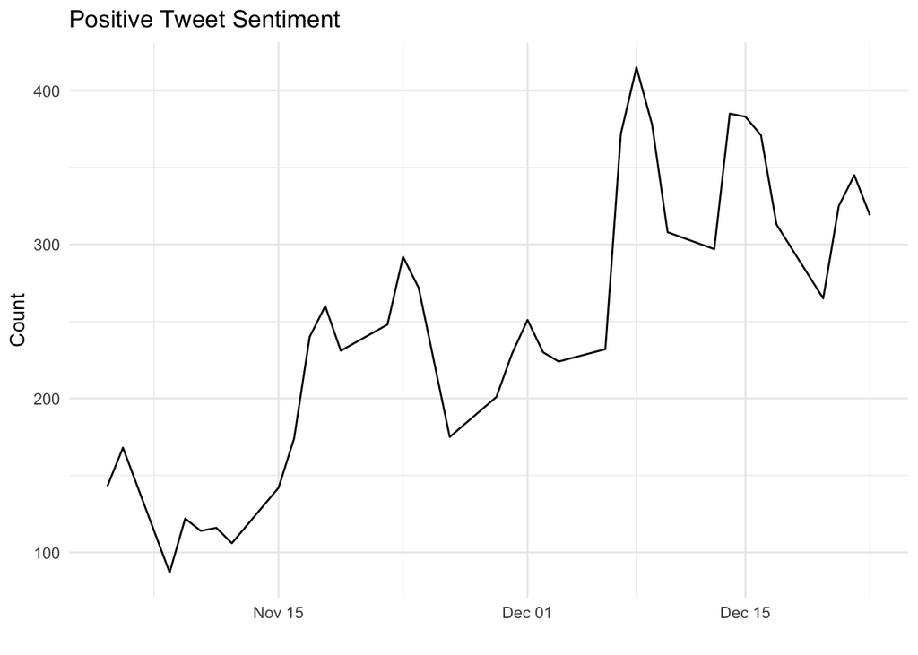

```r
library(ggthemes)
ggplot(final1, aes(x = date, y= positive)) + geom_line() + ylab("Count") +xlab("") + ggtitle("Positive Tweet Sentiment") +theme_minimal()
```

Write this final table to a csv file in order to use for analysis.

```r
#converting dataframes into csv files
write_csv(t3, "CompleteProjectTable.csv")
write_csv(final1, "ProjectTable.csv")
```

Import libraries that will be used for modeling.

```r
library(timetk)
library(modeltime)
library(tidymodels)
#read in data for modeling
d = read_csv("ProjectTable.csv")
d %>% head
```

```
## # A tibble: 6 × 30
##   date        TSLA anticipation positive trust  fear negative sadness disgust
##   <date>     <dbl>        <dbl>    <dbl> <dbl> <dbl>    <dbl>   <dbl>   <dbl>
## 1 2021-11-04     0           56      143    60    41       71      32      16
## 2 2021-11-05     0           70      168    93    38       62      31       7
## 3 2021-11-08     0           45       87    47    22       38      12       5
## 4 2021-11-09     2           63      122    60    29       58      23       7
## 5 2021-11-10     2           56      114    54    45       53      20       8
## 6 2021-11-11     1           43      116    61    35       55      28       6
## # … with 21 more variables: joy <dbl>, surprise <dbl>, anger <dbl>,
## #   symbol <chr>, open <dbl>, high <dbl>, low <dbl>, close <dbl>, volume <dbl>,
## #   adjusted <dbl>, TSLA1 <dbl>, anticipation1 <dbl>, positive1 <dbl>,
## #   trust1 <dbl>, fear1 <dbl>, negative1 <dbl>, sadness1 <dbl>, disgust1 <dbl>,
## #   joy1 <dbl>, surprise1 <dbl>, anger1 <dbl>
```

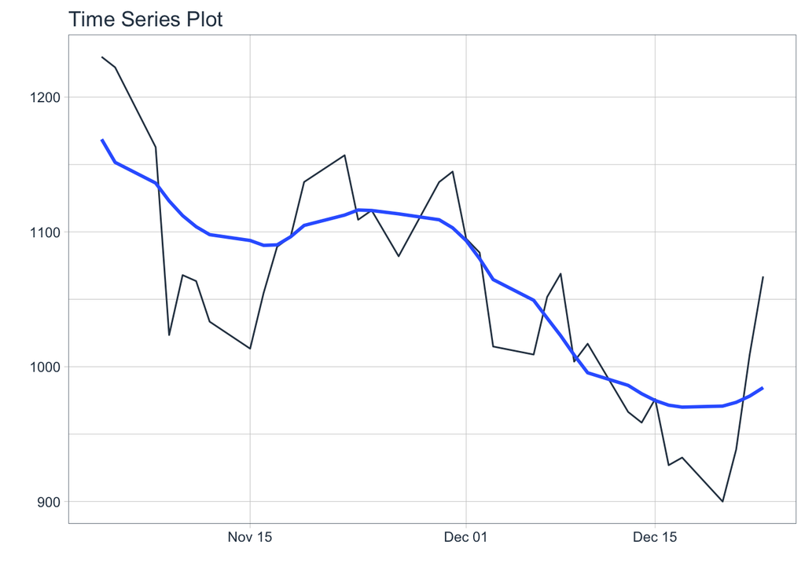

```r
d %>% plot_time_series(date, adjusted, .interactive = F)
```

```r
d
```

```
## # A tibble: 35 × 30
##    date        TSLA anticipation positive trust  fear negative sadness disgust
##    <date>     <dbl>        <dbl>    <dbl> <dbl> <dbl>    <dbl>   <dbl>   <dbl>
##  1 2021-11-04     0           56      143    60    41       71      32      16
##  2 2021-11-05     0           70      168    93    38       62      31       7
##  3 2021-11-08     0           45       87    47    22       38      12       5
##  4 2021-11-09     2           63      122    60    29       58      23       7
##  5 2021-11-10     2           56      114    54    45       53      20       8
##  6 2021-11-11     1           43      116    61    35       55      28       6
##  7 2021-11-12     2           47      106    61    28       56      25       6
##  8 2021-11-15     2           64      142    86    43       63      22       4
##  9 2021-11-16     1          104      174   115    58       85      30       6
## 10 2021-11-17     4          120      240   143    84      154      77      34
## # … with 25 more rows, and 21 more variables: joy <dbl>, surprise <dbl>,
## #   anger <dbl>, symbol <chr>, open <dbl>, high <dbl>, low <dbl>, close <dbl>,
## #   volume <dbl>, adjusted <dbl>, TSLA1 <dbl>, anticipation1 <dbl>,
## #   positive1 <dbl>, trust1 <dbl>, fear1 <dbl>, negative1 <dbl>,
## #   sadness1 <dbl>, disgust1 <dbl>, joy1 <dbl>, surprise1 <dbl>, anger1 <dbl>
```

Set seed to control randomness in split and split data into training and testing set.

```r
set.seed(8)
splits  = d %>% time_series_split(date_var = date, assess = "1 week",
                        cumulative = TRUE)
trs = training(splits)
ts = testing(splits)
trs %>% head
```

```
## # A tibble: 6 × 30
##   date        TSLA anticipation positive trust  fear negative sadness disgust
##   <date>     <dbl>        <dbl>    <dbl> <dbl> <dbl>    <dbl>   <dbl>   <dbl>
## 1 2021-11-04     0           56      143    60    41       71      32      16
## 2 2021-11-05     0           70      168    93    38       62      31       7
## 3 2021-11-08     0           45       87    47    22       38      12       5
## 4 2021-11-09     2           63      122    60    29       58      23       7
## 5 2021-11-10     2           56      114    54    45       53      20       8
## 6 2021-11-11     1           43      116    61    35       55      28       6
## # … with 21 more variables: joy <dbl>, surprise <dbl>, anger <dbl>,
## #   symbol <chr>, open <dbl>, high <dbl>, low <dbl>, close <dbl>, volume <dbl>,
## #   adjusted <dbl>, TSLA1 <dbl>, anticipation1 <dbl>, positive1 <dbl>,
## #   trust1 <dbl>, fear1 <dbl>, negative1 <dbl>, sadness1 <dbl>, disgust1 <dbl>,
## #   joy1 <dbl>, surprise1 <dbl>, anger1 <dbl>
```

Make a basic recipe/formula to model the adjusted price of TSLA using the lagged variables.

```r
basicRecipe = recipe(adjusted~ TSLA1 + anticipation1 + positive1 + trust1 + fear1 + negative1 + sadness1 + disgust1 + joy1 + surprise1 + anger1 + date, trs)


basicRecipe %>% prep() %>% juice()
```

```
## # A tibble: 30 × 13
##    TSLA1 anticipation1 positive1 trust1 fear1 negative1 sadness1 disgust1  joy1
##    <dbl>         <dbl>     <dbl>  <dbl> <dbl>     <dbl>    <dbl>    <dbl> <dbl>
##  1     0             9        12      8     4         6        2        1     5
##  2     0            56       143     60    41        71       32       16    36
##  3     0            19        32     17    11        14        3        1    12
##  4     0            45        87     47    22        38       12        5    18
##  5     2            63       122     60    29        58       23        7    38
##  6     2            56       114     54    45        53       20        8    30
##  7     1            43       116     61    35        55       28        6    31
##  8     0             9        27     17     5        11        6        2     9
##  9     2            64       142     86    43        63       22        4    41
## 10     1           104       174    115    58        85       30        6    58
## # … with 20 more rows, and 4 more variables: surprise1 <dbl>, anger1 <dbl>,
## #   date <date>, adjusted <dbl>
```

Define the models that will be used. This is a regression problem, so engines are set accordingly. The prophet and ARIMA models will be used to predict stock price. XGboost versions of these models will also be used.

```r
prophet_reg = prophet_reg() %>%
    set_engine("prophet")
prophet_reg_b = prophet_boost() %>%
    set_engine("prophet_xgboost")
arima_reg = arima_reg() %>%
    set_engine("auto_arima")
arima_reg_b = arima_boost() %>%
    set_engine("auto_arima_xgboost")
```

I will define a basic workflow here with the regular model and basic recipe.

```r
bw = workflow() %>%  add_model(prophet_reg) %>% add_recipe(basicRecipe)
```

This section fits the model to the training dataset.

```r
m1 =  bw %>% fit(trs)
```

```
## Disabling yearly seasonality. Run prophet with yearly.seasonality=TRUE to override this.
```

```
## Disabling daily seasonality. Run prophet with daily.seasonality=TRUE to override this.
```

```
## n.changepoints greater than number of observations. Using 23
```

```r
m2 = bw %>% update_model(prophet_reg_b) %>%  fit(trs)
```

```
## Disabling yearly seasonality. Run prophet with yearly.seasonality=TRUE to override this.
```

```
## Disabling daily seasonality. Run prophet with daily.seasonality=TRUE to override this.
```

```
## n.changepoints greater than number of observations. Using 23
```

```r
m3 = bw %>% update_model(arima_reg) %>% fit(trs)
```

```
## frequency = 5 observations per 1 week
```

```r
m4 = bw %>% update_model(arima_reg_b) %>% fit(trs)
```

```
## frequency = 5 observations per 1 week
```

Now we will use the trained model and predict the test data set.

```r
mt = modeltime_table(m1, m2, m3, m4)
ct = mt %>% modeltime_calibrate(ts)
```

With these predictions we will find the MAE and RMSE to the accuracy of the predictions and compare the models.

```r
ct %>% modeltime_accuracy() %>% select(.model_id,
  .model_desc , mae, rmse) %>% table_modeltime_accuracy(.interactive = F)
```

Accuracy Table

| .model_id | .model_desc | mae | rmse |
| --- | --- | --- | --- |
| 1 | PROPHET W/ REGRESSORS | 78.14 | 93.28 |
| 2 | PROPHET W/ XGBOOST ERRORS | 59.56 | 61.95 |
| 3 | REGRESSION WITH ARIMA(1,0,0) ERRORS | 48.57 | 61.64 |
| 4 | ARIMA(0,1,0) W/ XGBOOST ERRORS | 86.28 | 102.30 |

Visualize the forecast for the stock prices.

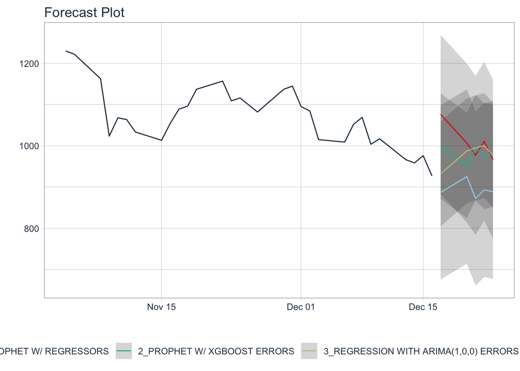

```r
ct %>% modeltime_forecast(new_data = ts, actual_data = trs) %>%
  plot_modeltime_forecast(.interactive = F)
```